# 基于岭回归的工资预测模型

## 任务背景

- 在处理较为复杂的数据的回归问题时，普通的线性回归算法通常会出现预测精度不够的问题。如果模型中的特征之间有相关关系，就会增加模型的复杂程度。当数据集中的特征之间有较强的线性相关性时，即特征之间出现严重的多重共线性时，用普通最小二乘法估计模型参数，往往参数估计的方差太大，此时，求解出来的模型就很不稳定。
- 这种时候较为常用岭回归(ridge regression, Tikhonov regularization)。这是一种专用于共线性数据分析的有偏估计回归方法，实质上是一种改良的最小二乘估计法，通过放弃最小二乘法的无偏性，以损失部分信息、降低精度为代价获得回归系数更为符合实际、更可靠的回归方法。

## 任务步骤

1. 计算相关系数矩阵并可视化
2. 学习划分训练集和测试集
3. 学习使用VIF判断多重共线性
4. 建立岭回归模型预测工资

**知识点**

1. 多重共线性问题可以使用岭回归模型解决
2. 多重共线性可以使用VIF进行判断
3. 相关系数矩阵可以判断特征值相关性

**实验目的**

1. 学习计算相关系数矩阵并可视化
2. 学习划分训练集和测试集
3. 学习使用VIF判断多重共线性
4. 学习建立岭回归模型预测工资

# 读取数据

**这些数据包括来自CPS的534个样本，包括工资和工人的其他特征，如性别、受教育年限、工作经验、职业状况、居住区域和是否工会成员，字段解释如下:**

- EDUCATION: Number of years of education.
- SOUTH: Indicator variable for Southern Region (1=Person lives in South, 0=Person lives elsewhere).
- SEX: Indicator variable for sex (1=Female, 0=Male).
- EXPERIENCE: Number of years of work experience.
- UNION: Indicator variable for union membership (1=Union member, 0=Not union member).
- WAGE: Wage (dollars per hour).
- AGE: Age (years).
- RACE: Race (1=Other, 2=Hispanic, 3=White).
- OCCUPATION: Occupational category (1=Management, 2=Sales, 3=Clerical, 4=Service, 5=Professional, 6=Other).
- SECTOR: Sector (0=Other, 1=Manufacturing, 2=Construction).
- MARR: Marital Status (0=Unmarried, 1=Married)

```python
import pandas as pd
df_names = ['EDUCATION','SOUTH','SEX','EXPERIENCE','UNION','WAGE','AGE','RACE','OCCUPATION','SECTOR','MARR']
df = pd.read_csv('./experiment/data/CPS_85_Wages.txt',sep='\t',names=df_names)
df.shape
```

```
(534, 11)
```

# 描述性分析与可视化分析

```python
# 1.查看df的前五项

df.head()
```

|  | EDUCATION | SOUTH | SEX | EXPERIENCE | UNION | WAGE | AGE | RACE | OCCUPATION | SECTOR | MARR |
| --- | --- | --- | --- | --- | --- | --- | --- | --- | --- | --- | --- |
| 0 | 8 | 0 | 1 | 21 | 0 | 5.10 | 35 | 2 | 6 | 1 | 1 |
| 1 | 9 | 0 | 1 | 42 | 0 | 4.95 | 57 | 3 | 6 | 1 | 1 |
| 2 | 12 | 0 | 0 | 1 | 0 | 6.67 | 19 | 3 | 6 | 1 | 0 |
| 3 | 12 | 0 | 0 | 4 | 0 | 4.00 | 22 | 3 | 6 | 0 | 0 |
| 4 | 12 | 0 | 0 | 17 | 0 | 7.50 | 35 | 3 | 6 | 0 | 1 |

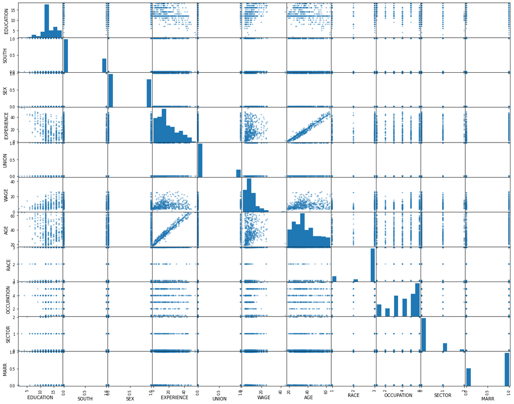

```python
#2.查看散点图矩阵

import matplotlib.pyplot as plt
from pandas.plotting import scatter_matrix
scatter_matrix(df,figsize=(20,16))
plt.show()
```

```python
# 3.查看相关系数矩阵

import numpy as np
correlations = df.corr()
correlations
```

|  | EDUCATION | SOUTH | SEX | EXPERIENCE | UNION | WAGE | AGE | RACE | OCCUPATION | SECTOR | MARR |
| --- | --- | --- | --- | --- | --- | --- | --- | --- | --- | --- | --- |
| EDUCATION | 1.000000 | -0.140143 | 0.002031 | -0.352676 | -0.023886 | 0.381922 | -0.150019 | 0.096016 | -0.205998 | -0.188853 | -0.035522 |
| SOUTH | -0.140143 | 1.000000 | -0.021264 | -0.007407 | -0.086275 | -0.141031 | -0.038665 | -0.114967 | 0.014740 | 0.000430 | 0.006523 |
| SEX | 0.002031 | -0.021264 | 1.000000 | 0.075230 | -0.157027 | -0.205371 | 0.079179 | 0.026924 | -0.220920 | -0.170764 | 0.011225 |
| EXPERIENCE | -0.352676 | -0.007407 | 0.075230 | 1.000000 | 0.117926 | 0.087060 | 0.977961 | -0.023990 | -0.021779 | 0.111500 | 0.270900 |
| UNION | -0.023886 | -0.086275 | -0.157027 | 0.117926 | 1.000000 | 0.161766 | 0.119466 | -0.086544 | 0.229347 | 0.095849 | 0.093164 |
| WAGE | 0.381922 | -0.141031 | -0.205371 | 0.087060 | 0.161766 | 1.000000 | 0.176967 | 0.094708 | -0.049069 | 0.045361 | 0.100579 |
| AGE | -0.150019 | -0.038665 | 0.079179 | 0.977961 | 0.119466 | 0.176967 | 1.000000 | -0.004196 | -0.069265 | 0.075918 | 0.278947 |
| RACE | 0.096016 | -0.114967 | 0.026924 | -0.023990 | -0.086544 | 0.094708 | -0.004196 | 1.000000 | 0.014694 | 0.001641 | 0.043644 |
| OCCUPATION | -0.205998 | 0.014740 | -0.220920 | -0.021779 | 0.229347 | -0.049069 | -0.069265 | 0.014694 | 1.000000 | 0.364584 | -0.011384 |
| SECTOR | -0.188853 | 0.000430 | -0.170764 | 0.111500 | 0.095849 | 0.045361 | 0.075918 | 0.001641 | 0.364584 | 1.000000 | 0.056050 |
| MARR | -0.035522 | 0.006523 | 0.011225 | 0.270900 | 0.093164 | 0.100579 | 0.278947 | 0.043644 | -0.011384 | 0.056050 | 1.000000 |

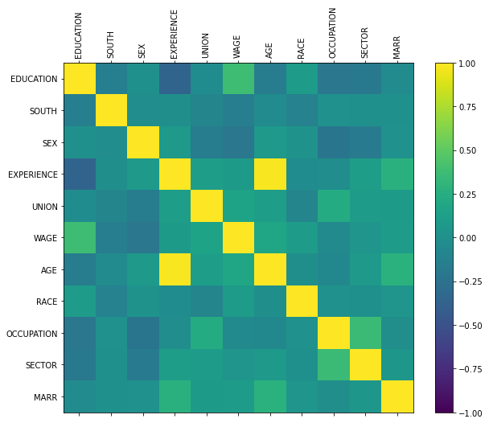

```python
#4.相关系数矩阵可视化

fig = plt.figure(figsize=(10,8))
ax = fig.add_subplot(111)
cax = ax.matshow(correlations, vmin=-1, vmax=1)
fig.colorbar(cax)
ticks = np.arange(0,df.shape[1],1)
ax.set_xticks(ticks)
ax.set_yticks(ticks)
ax.set_xticklabels(df.columns,rotation=90)
ax.set_yticklabels(df.columns)
plt.show()
```

# 数据处理

```python
#1.划分自变量与因变量

X = df.loc[:,df.columns != 'WAGE']
y = df['WAGE']
X.sample(6)
```

|  | EDUCATION | SOUTH | SEX | EXPERIENCE | UNION | AGE | RACE | OCCUPATION | SECTOR | MARR |
| --- | --- | --- | --- | --- | --- | --- | --- | --- | --- | --- |
| 468 | 18 | 0 | 0 | 33 | 1 | 57 | 3 | 5 | 0 | 0 |
| 425 | 8 | 1 | 1 | 45 | 0 | 59 | 3 | 4 | 0 | 0 |
| 121 | 12 | 0 | 1 | 15 | 0 | 33 | 3 | 6 | 1 | 0 |
| 43 | 9 | 0 | 1 | 16 | 0 | 31 | 3 | 6 | 1 | 1 |
| 483 | 18 | 0 | 1 | 18 | 1 | 42 | 3 | 5 | 0 | 1 |
| 297 | 14 | 1 | 1 | 15 | 0 | 35 | 3 | 3 | 0 | 1 |

```python
#2.划分训练集与测试集

from sklearn.model_selection import train_test_split
X_tr,X_ts,y_tr,y_ts = train_test_split(X,y,test_size=0.2)
len(y_tr),len(y_ts)
```

```
(427, 107)
```

# 共线性分析

```python
#1.使用VIF检查方差膨胀因子

from statsmodels.stats.outliers_influence import variance_inflation_factor
vif = pd.DataFrame()
vif["features"] = X.columns
vif["VIF Factor"] = [variance_inflation_factor(X.values, i) for i in range(X.shape[1])]
vif
```

|  | features | VIF Factor |
| --- | --- | --- |
| 0 | EDUCATION | 506.949214 |
| 1 | SOUTH | 1.477119 |
| 2 | SEX | 1.999971 |
| 3 | EXPERIENCE | 916.735039 |
| 4 | UNION | 1.366173 |
| 5 | AGE | 2744.731134 |
| 6 | RACE | 17.209783 |
| 7 | OCCUPATION | 9.251814 |
| 8 | SECTOR | 1.512347 |
| 9 | MARR | 3.177854 |

# 建立模型

```python
#1.使用岭回归建立模型

from sklearn.linear_model import Ridge
ridgereg = Ridge(alpha=0.001,normalize=True)
ridgereg.fit(X_tr,y_tr)
```

```
Ridge(alpha=0.001, normalize=True)
```

# 模型预测与评估

```python
#1.查看预测结果前5项

y_ts_pred = ridgereg.predict(X_ts)
y_ts_pred[:5]
```

```
array([ 9.57225664,  9.12826157, 10.71439421, 13.10906278,  6.51879919])
```

```python
#2.查看特征值系数

coef = pd.DataFrame()
coef["features"] = X.columns
coef["coef"] = ridgereg.coef_
coef.append({'features':'INTERCEPTION','coef':ridgereg.intercept_},ignore_index=True)
```

|  | features | coef |
| --- | --- | --- |
| 0 | EDUCATION | 0.853696 |
| 1 | SOUTH | -0.791917 |
| 2 | SEX | -2.112581 |
| 3 | EXPERIENCE | 0.075144 |
| 4 | UNION | 1.124040 |
| 5 | AGE | 0.010618 |
| 6 | RACE | 0.390914 |
| 7 | OCCUPATION | -0.230254 |
| 8 | SECTOR | 0.518238 |
| 9 | MARR | 0.766937 |
| 10 | INTERCEPTION | -3.488802 |

```python
#3.计算RMSE

rmse_ts = np.sqrt(np.mean(np.square(y_ts_pred-y_ts)))
rmse_ts
```

```
4.198424274480804
```

```python
#4.使用5折交叉验证计算RMSE

from sklearn.model_selection import cross_val_score
scores = cross_val_score(ridgereg,X,y,cv=5,scoring='neg_mean_squared_error')
rmse_cv = np.sqrt(-scores.mean())
rmse_cv
```

```
4.70309138071148
```

# 实验结论